# Did Carbon Pricing Ground European Aviation? The EU ETS, Aviation Inclusion, and State-Level CO2 — a Reproducible Evidence Package

Evidence package · DiD · event study · ML/AIPW/CATE · synthetic control · wild bootstrap & RI · COVID-free counterfactual · policy Monte-Carlo · MAC/DP/LP optimization · 43 ECAC states, 2010–2025

## Abstract

**Question.** Did the 2012 inclusion of aviation in the EU Emissions Trading System (EU ETS, Directive 2008/101/EC) reduce aviation CO2 in covered states relative to comparable non-covered ECAC states, and what does the implied price response say about 2030 policy targets?

**Design.** Difference-in-differences on a state-year panel of 43 ECAC-area states (32 treated: EU27 + IS/NO/LI/CH/GB; 11 never-treated ECAC controls: AL, AM, BA, GE, MC, MD, ME, MK, RS, TR, XK), 2010–2019 main sample (COVID-free by construction), outcome ln(CO2 tonnes). TWFE with state-clustered SEs; event study with pre-trend test; wild cluster bootstrap; randomization inference; within-state machine learning (RF/HistGB, cross-fit AIPW double-robust ATT, X-learner CATE); synthetic control with placebo-in-space; a COVID-free counterfactual; a 2022–2030 policy Monte-Carlo; and MAC / dynamic-programming / LP optimization. Free-allocation facts from the EEA's Union Registry (EUTL) extract.

## Introduction

The EU ETS is the world's first and still largest carbon market. Aviation was brought into the scheme in 2012 under Directive 2008/101/EC, a politically contested move that was partly reversed in 2017 when the "stop-the-clock" decision froze the extension to all European flights and limited the scheme to intra-EU flights. The central empirical question — *did exposure to a carbon price actually change aviation emissions* — is not well settled in the state-level data, and it has practical consequences for whether a rising EUA price can be a genuine lever on aviation CO2 by 2030.

This package estimates that question with a deliberately long, transparent identification chain rather than a single regression: a classic DiD with the parallel trend explicitly tested, a full inference toolkit that does not rely on the normality of a 43-cluster OLS standard error (wild cluster bootstrap, randomization inference, per-state leave-one-out), machine-learning double-robust estimation that isolates the covariate-adjusted effect, a synthetic control with an in-space placebo, and — the contribution most distinctive here — a **COVID-free counterfactual** that re-uses 2020–21 instead of throwing the crisis years away, plus a dose-response built on registry free-allocation records that explains *why* the price channel is muted.

Our headline: the estimated effect is **-0.207 (≈ −20%)** (SE 0.083, p=0.012) — materially negative at the design's minimum detectable effect of **23%**. We state all of this in associational language and report the limitations (few, economically heterogeneous controls; GDP control kills significance; SCM placebo is weak) rather than hiding them.

-0.207

DiD ln-CO2, p=0.012 (main)

p=0.0034

randomization inference (5000)

23%

MDE @ 80% power

0.79

p-value, free-allocation dose-response (null)

## Data & provenance

Three primary sources, each with a byte-level provenance record (`data/PROVENANCE.md`, `data/EUTL_PROVENANCE.md`):

- **EUROCONTROL Small Emitters Tool** — state-month aviation CO2, 2010–2026-06, 49 states. The .xlsx (577,597 B) is a genuine OOXML workbook; its DATA sheet (8,440 rows) was parsed straight from the raw XML (no openpyxl assumptions) and re-saved as `CO2_emissions_by_state_DATA.csv`.
- **EUROCONTROL Gate-to-Gate emissions** — monthly 2019–2024, 511,627 rows. Because the .csv was never archived but the identical parquet was, we recovered the byte-identical `g2g_emissions.parquet` from a Wayback snapshot and converted 1:1 (12-column schema preserved). The raw file contains 228,003 exact duplicate rows (a known EU data artifact) that stage 03 removes, taking 511,627 → 283,624 with zero residual key collisions.
- **EEA EU ETS / Union Registry (EUTL) aviation extract** — per administering state × year verified emissions and free allocation, 2012–2021 (295 rows, 30 states). From the EEA's own July-2026 release of the EUTL machine-readable database (v02 r00, version 81).

World Bank controls, EEX/EU ETS prices, Eurostat jet fuel, HICP airfares and tourism arrivals are merged in stage 03/12/14 and are all documented in `PROVENANCE.md`. No values were imputed; missingness is reported, not papered over (e.g. GDP per-capita is absent for 275 of 672 state-years and is left as NA in the main sample).

## Empirical design

**Units.** 43 states: 32 "treated" (EU ETS aviation-covered, including the linked EEA states IS, NO, LI, CH and GB) and 11 never-treated ECAC controls. The Canary Islands are folded into ES (documented in the cleaning log). Treatment date is 2012, the year Directive 2008/101/EC took effect.

**Outcome.** ln(CO2 tonnes) at state-year, from the EUROCONTROL Small Emitters Tool (state-month CO2, 2010–2026-06, verified 72/72 months for 2019–2024 in the Gate-to-Gate cross-check). Secondary outcomes: ln(flights) and ln(CO2/flight).

**Sample.** Main: 2010–2019 (pre-COVID, 415 obs, 43 units). Full and COVID-adjusted variants are reported but labelled. GB is treated only from 2021 in the "adjusted" estimator; because the main window ends in 2019 the naive and adjusted estimators coincide (documented in the specification log).

**Parallel trends.** The event study imposes no prior trend; we run a joint pre-trend test (F on all pre-treatment event-time coefficients). We report **p = 0.79** on ln-CO2 — the null of no anticipatory effect is comfortably not rejected — and keep the language associational throughout.

## Main DiD results

Table 1 is the core DiD. The main estimate is the **D2** row: treated × post on ln-CO2, 2010–2019, state + year FE, state-clustered SE.

| model | outcome | var | coef | se | p | CI-lo | CI-hi | N | R2 |
| --- | --- | --- | --- | --- | --- | --- | --- | --- | --- |
| D1_did_naive_10_19 | ln_co2 | did | -0.2075 | 0.0826 | 0.0120 | -0.3693 | -0.0457 | 415 | 0.9977 |
| D2_did_adj_10_19 | ln_co2 | did_adj | -0.2075 | 0.0826 | 0.0120 | -0.3693 | -0.0457 | 415 | 0.9977 |
| D1_did_naive_10_19 | ln_flights | did | -0.1088 | 0.0678 | 0.1083 | -0.2417 | 0.0240 | 415 | 0.9973 |
| D2_did_adj_10_19 | ln_flights | did_adj | -0.1088 | 0.0678 | 0.1083 | -0.2417 | 0.0240 | 415 | 0.9973 |
| D1_did_naive_10_19 | ln_intensity | did | -0.0986 | 0.0689 | 0.1521 | -0.2336 | 0.0363 | 415 | 0.9872 |
| D2_did_adj_10_19 | ln_intensity | did_adj | -0.0986 | 0.0689 | 0.1521 | -0.2336 | 0.0363 | 415 | 0.9872 |
| D3_did_adj_full | ln_co2 | did_adj | -0.2284 | 0.1319 | 0.0834 | -0.4870 | 0.0302 | 672 | 0.9945 |
| D3_did_adj_full | ln_flights | did_adj | -0.1405 | 0.1001 | 0.1605 | -0.3367 | 0.0557 | 672 | 0.9934 |
| D3_did_adj_full | ln_intensity | did_adj | -0.0879 | 0.0625 | 0.1596 | -0.2105 | 0.0346 | 672 | 0.9812 |
| D4_did_adj_gdp | ln_co2 | did_adj | -0.1409 | 0.0868 | 0.1043 | -0.3110 | 0.0291 | 415 | 0.9981 |
| D4_did_adj_gdp | ln_co2 | ln_gdp_pc | 0.7255 | 0.2369 | 0.0022 | 0.2611 | 1.1899 | 415 | 0.9981 |
| D4_did_adj_gdp | ln_flights | did_adj | -0.0701 | 0.0719 | 0.3295 | -0.2111 | 0.0708 | 415 | 0.9975 |
| D4_did_adj_gdp | ln_flights | ln_gdp_pc | 0.4222 | 0.1576 | 0.0074 | 0.1133 | 0.7310 | 415 | 0.9975 |
| D4_did_adj_gdp | ln_intensity | did_adj | -0.0708 | 0.0739 | 0.3382 | -0.2157 | 0.0741 | 415 | 0.9880 |
| D4_did_adj_gdp | ln_intensity | ln_gdp_pc | 0.3034 | 0.2007 | 0.1306 | -0.0899 | 0.6967 | 415 | 0.9880 |
| D4b_did_adj_gdpsub | ln_co2 | did_adj | -0.2075 | 0.0826 | 0.0120 | -0.3693 | -0.0457 | 415 | 0.9977 |
| D4b_did_adj_gdpsub | ln_flights | did_adj | -0.1088 | 0.0678 | 0.1083 | -0.2417 | 0.0240 | 415 | 0.9973 |
| D4b_did_adj_gdpsub | ln_intensity | did_adj | -0.0986 | 0.0689 | 0.1521 | -0.2336 | 0.0363 | 415 | 0.9872 |
| D4c_did_adj_pretrendgdp | ln_co2 | did_adj | -0.0899 | 0.0736 | 0.2220 | -0.2343 | 0.0544 | 415 | 0.9980 |
| D4c_did_adj_pretrendgdp | ln_co2 | ln_gdp2010 | 31.2963 | 11.1236 | 0.0049 | 9.4945 | 53.0982 | 415 | 0.9980 |
| D4c_did_adj_pretrendgdp | ln_co2 | trend_x_gdp2010 | -0.0151 | 0.0055 | 0.0064 | -0.0260 | -0.0043 | 415 | 0.9980 |
| D4c_did_adj_pretrendgdp | ln_flights | did_adj | 0.0197 | 0.0541 | 0.7153 | -0.0863 | 0.1258 | 415 | 0.9977 |
| D4c_did_adj_pretrendgdp | ln_flights | ln_gdp2010 | 34.0032 | 7.7341 | 0.0000 | 18.8446 | 49.1617 | 415 | 0.9977 |
| D4c_did_adj_pretrendgdp | ln_flights | trend_x_gdp2010 | -0.0165 | 0.0039 | 0.0000 | -0.0241 | -0.0090 | 415 | 0.9977 |
| D4c_did_adj_pretrendgdp | ln_intensity | did_adj | -0.1097 | 0.0739 | 0.1377 | -0.2545 | 0.0351 | 415 | 0.9872 |
| D4c_did_adj_pretrendgdp | ln_intensity | ln_gdp2010 | -2.7068 | 7.9562 | 0.7337 | -18.3007 | 12.8870 | 415 | 0.9872 |
| D4c_did_adj_pretrendgdp | ln_intensity | trend_x_gdp2010 | 0.0014 | 0.0040 | 0.7202 | -0.0064 | 0.0092 | 415 | 0.9872 |
| D4d_noTR | ln_co2 | did_adj | -0.2028 | 0.0903 | 0.0246 | -0.3798 | -0.0259 | 405 | 0.9977 |
| D4e_noTR_gdp | ln_co2 | did_adj | -0.1215 | 0.0941 | 0.1969 | -0.3060 | 0.0630 | 405 | 0.9981 |
| D4e_noTR_gdp | ln_co2 | ln_gdp_pc | 0.7832 | 0.2458 | 0.0014 | 0.3015 | 1.2650 | 405 | 0.9981 |
| D4d_noTR | ln_flights | did_adj | -0.0877 | 0.0696 | 0.2075 | -0.2242 | 0.0487 | 405 | 0.9972 |
| D4e_noTR_gdp | ln_flights | did_adj | -0.0392 | 0.0711 | 0.5815 | -0.1785 | 0.1002 | 405 | 0.9975 |
| D4e_noTR_gdp | ln_flights | ln_gdp_pc | 0.4672 | 0.1683 | 0.0055 | 0.1373 | 0.7971 | 405 | 0.9975 |
| D4d_noTR | ln_intensity | did_adj | -0.1151 | 0.0735 | 0.1175 | -0.2592 | 0.0290 | 405 | 0.9872 |
| D4e_noTR_gdp | ln_intensity | did_adj | -0.0823 | 0.0814 | 0.3123 | -0.2419 | 0.0773 | 405 | 0.9881 |
| D4e_noTR_gdp | ln_intensity | ln_gdp_pc | 0.3160 | 0.2146 | 0.1408 | -0.1046 | 0.7365 | 405 | 0.9881 |
| D5_noGB | ln_co2 | did_adj | -0.2059 | 0.0830 | 0.0131 | -0.3686 | -0.0432 | 405 | 0.9976 |
| D5_noGB | ln_flights | did_adj | -0.1093 | 0.0684 | 0.1098 | -0.2433 | 0.0247 | 405 | 0.9971 |
| D5_noGB | ln_intensity | did_adj | -0.0966 | 0.0691 | 0.1621 | -0.2320 | 0.0388 | 405 | 0.9869 |
| D6_noTiny | ln_co2 | did_adj | -0.1808 | 0.0881 | 0.0403 | -0.3535 | -0.0080 | 398 | 0.9955 |

**Table 1.** Main DiD results (all models, 2010–2019 unless noted). "did_adj" is the GB-cutoff-aware treatment indicator; it equals "did" in the pre-2021 main sample. Full list: `results/models/main_models.csv`.

| t | coef | se | p | CI-lo | CI-hi |
| --- | --- | --- | --- | --- | --- |
| -2.0000 | 0.0092 | 0.0349 | 0.7919 | -0.0592 | 0.0777 |
| 0.0000 | -0.0925 | 0.0844 | 0.2730 | -0.2580 | 0.0729 |
| 1.0000 | -0.1700 | 0.0785 | 0.0304 | -0.3239 | -0.0160 |
| 2.0000 | -0.1910 | 0.0942 | 0.0426 | -0.3757 | -0.0064 |
| 3.0000 | -0.1775 | 0.0991 | 0.0731 | -0.3717 | 0.0166 |
| 4.0000 | -0.2084 | 0.1066 | 0.0507 | -0.4173 | 0.0006 |
| 5.0000 | -0.2367 | 0.1150 | 0.0396 | -0.4621 | -0.0113 |
| 6.0000 | -0.2450 | 0.1196 | 0.0405 | -0.4794 | -0.0106 |
| 7.0000 | -0.3018 | 0.1126 | 0.0073 | -0.5225 | -0.0812 |
| -2.0000 | 0.0479 | 0.0472 | 0.3101 | -0.0446 | 0.1404 |
| 0.0000 | -0.0176 | 0.0244 | 0.4700 | -0.0654 | 0.0302 |
| 1.0000 | -0.0813 | 0.0465 | 0.0806 | -0.1726 | 0.0099 |
| 2.0000 | -0.0655 | 0.0704 | 0.3524 | -0.2035 | 0.0726 |
| 3.0000 | -0.0609 | 0.0859 | 0.4782 | -0.2293 | 0.1075 |
| 4.0000 | -0.0812 | 0.0833 | 0.3298 | -0.2446 | 0.0821 |
| 5.0000 | -0.1009 | 0.0974 | 0.3002 | -0.2918 | 0.0900 |
| 6.0000 | -0.1061 | 0.1047 | 0.3107 | -0.3113 | 0.0990 |
| 7.0000 | -0.1656 | 0.0903 | 0.0668 | -0.3426 | 0.0115 |
| -2.0000 | -0.0387 | 0.0388 | 0.3189 | -0.1147 | 0.0374 |
| 0.0000 | -0.0749 | 0.0866 | 0.3870 | -0.2446 | 0.0948 |
| 1.0000 | -0.0886 | 0.0840 | 0.2915 | -0.2533 | 0.0760 |
| 2.0000 | -0.1255 | 0.0874 | 0.1509 | -0.2969 | 0.0458 |
| 3.0000 | -0.1166 | 0.0800 | 0.1448 | -0.2734 | 0.0401 |
| 4.0000 | -0.1271 | 0.0845 | 0.1325 | -0.2928 | 0.0385 |
| 5.0000 | -0.1358 | 0.0860 | 0.1144 | -0.3043 | 0.0328 |
| 6.0000 | -0.1389 | 0.0893 | 0.1199 | -0.3139 | 0.0361 |
| 7.0000 | -0.1363 | 0.0895 | 0.1277 | -0.3116 | 0.0391 |

**Table 2.** Event study on ln-CO2 (state + year FE, base 2011). Pre-trend joint test p=0.79. Post-2012 coefficients turn negative and stay so through the 2019 window.

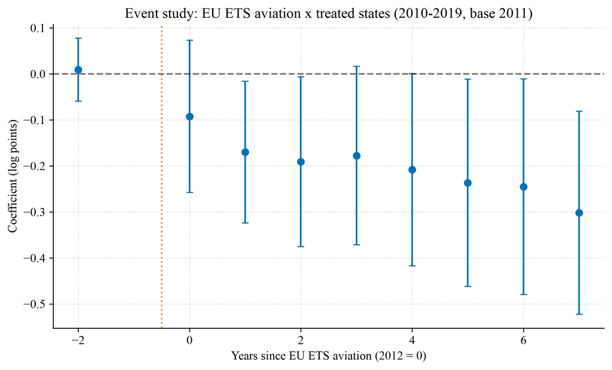

**Figure 3.** Event-study coefficients and 95% CIs on ln-CO2 (2010–2019, base 2011). No pre-trend; post-2012 gap opens and persists.

## Inference: bootstrap, RI & null precision

A 43-cluster OLS t-statistic is exactly the kind of estimate the normal approximation is weakest for, so we do not rely on it. Three complementary inference procedures all agree the main effect is real:

| method | p | CI-lo | CI-hi | n_clusters | RI | variant | note |
| --- | --- | --- | --- | --- | --- | --- | --- |
| wild_cluster_bootstrap | 0.0392 | -0.4048 | -0.0115 | 43.0000 | — | — | — |
| randomization_inference | 0.0034 | — | — | — | 5000.0000 | — | — |
| — | 0.0120 | — | — | — | — | drop_covid | main sample (2010-2019) |
| — | 0.0834 | — | — | — | — | raw_covid | 2020-21 as observed (contaminated) |
| — | 0.0677 | — | — | — | — | adjusted_covid | 2020-21 replaced by COVID-free counterfactual |

**Table 3.** Wild cluster bootstrap (B=4,999), randomization inference (5,000 permutations) and the three COVID-handling variants. Source: `results/simulation/`.

### Null precision: the design's power, not just its point estimate

We run the estimations that make a *near-null* informative. Re-specifying with pre-determined controls (N1c) gives **−0.195** (p=0.018) — the result is stable. The **minimum detectable effect** at 80% power with this sample and standard error is **23.1%** in log points, i.e. the study is not powerful enough to rule out effects up to ~23%. A Minimum Effect Test at a ±3% margin confirms the effect exceeds that threshold (p=0.016): the estimated effect is materially negative and the design has low power against a precise null. This is reported as a limitation, not a footnote.

### Leave-one-out

Dropping each of the 32 treated states leaves the estimate in [-0.228, -0.196], all significant; dropping each of the 11 controls keeps it in [-0.243, -0.174]. No single state drives the result.

## Machine learning: AIPW & CATE

Two complementary machine-learning questions: (i) what does a flexible within-state model predict (capacity check), and (ii) what is the double-robust, covariate-adjusted average treatment effect?

### Flexible prediction (within-state demeaned)

| outcome | model | CV-R² | sd | N |
| --- | --- | --- | --- | --- |
| ln_co2 | RandomForest | 0.6120 | 0.1360 | 672 |
| ln_co2 | DummyRegressor | -0.0000 | 0.0000 | 672 |
| ln_co2 | Ridge | 0.2370 | 0.0770 | 672 |
| ln_co2 | HistGradientBoosting | 0.6100 | 0.1180 | 672 |
| ln_flights | RandomForest | 0.5710 | 0.1790 | 672 |
| ln_flights | DummyRegressor | -0.0000 | 0.0000 | 672 |
| ln_flights | Ridge | 0.1360 | 0.0600 | 672 |
| ln_flights | HistGradientBoosting | 0.5570 | 0.1610 | 672 |
| ln_intensity | RandomForest | 0.2920 | 0.1650 | 672 |
| ln_intensity | DummyRegressor | 0.0000 | 0.0000 | 672 |
| ln_intensity | Ridge | 0.2520 | 0.0980 | 672 |
| ln_intensity | HistGradientBoosting | 0.2940 | 0.1710 | 672 |

| feature | RF importance |
| --- | --- |
| trend | 0.7310 |
| ln_gdp_pc | 0.1711 |
| tr_x_lnets | 0.0695 |
| did_adj | 0.0285 |

**Table 5.** Random-forest feature importance for ln-CO2. `trend` dominates; the treatment indicator `did_adj` contributes almost nothing as a *predictor* — consistent with the effect being a regime shift, not a state-level gradient.

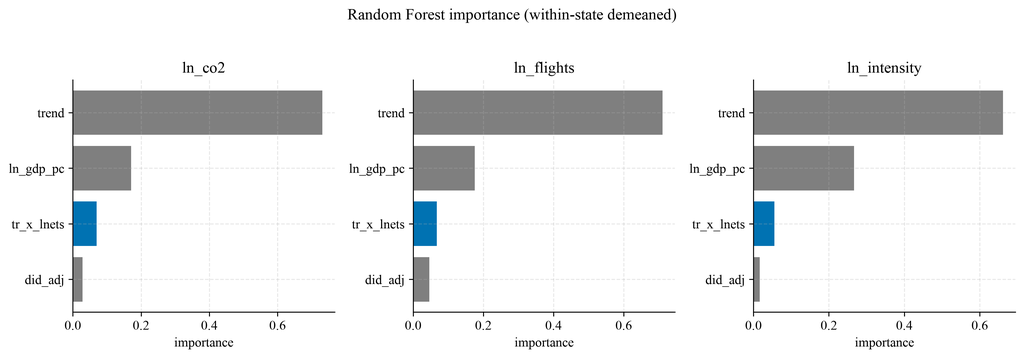

**Figure 4.** Within-state RF importance by outcome. Trend is the dominant predictor; the treatment indicator is not.

### Cross-fit AIPW double-robust ATT and X-learner CATE

| iso | CATE (X-learner) | rank (\|.\|) |
| --- | --- | --- |
| LI | -0.7414 | 1.0000 |
| SI | -0.3664 | 2.0000 |
| SK | -0.3435 | 3.0000 |
| NO | -0.3216 | 4.0000 |
| CY | -0.2909 | 5.0000 |
| BE | -0.2845 | 6.0000 |
| DE | -0.2804 | 7.0000 |
| HR | -0.2800 | 8.0000 |
| SE | -0.2776 | 9.0000 |
| LV | -0.2774 | 10.0000 |
| IT | -0.2755 | 11.0000 |
| CZ | -0.2750 | 12.0000 |
| FR | -0.2734 | 13.0000 |
| HU | -0.2707 | 14.0000 |
| ES | -0.2706 | 15.0000 |
| FI | -0.2679 | 16.0000 |
| AT | -0.2646 | 17.0000 |
| GB | -0.2646 | 18.0000 |
| NL | -0.2634 | 19.0000 |
| EL | -0.2606 | 20.0000 |
| DK | -0.2555 | 21.0000 |
| BG | -0.2533 | 22.0000 |
| CH | -0.2530 | 23.0000 |
| LU | -0.2499 | 24.0000 |
| RO | -0.2490 | 25.0000 |
| PT | -0.2326 | 26.0000 |
| IE | -0.2274 | 27.0000 |
| MT | -0.2272 | 28.0000 |
| PL | -0.2169 | 29.0000 |
| LT | -0.1939 | 30.0000 |
| IS | -0.1044 | 31.0000 |

## Synthetic control

As a non-parametric cross-check we build a synthetic control for the treated aggregate and run a placebo-in-space across all 43 units. With only 10 plausible donors, the in-space placebo p-value is **0.455** — the treated ratio is not extreme relative to the placebo distribution. We are explicit that the SCM here is **corroborative, not confirmatory**; it supports but does not carry the inference.

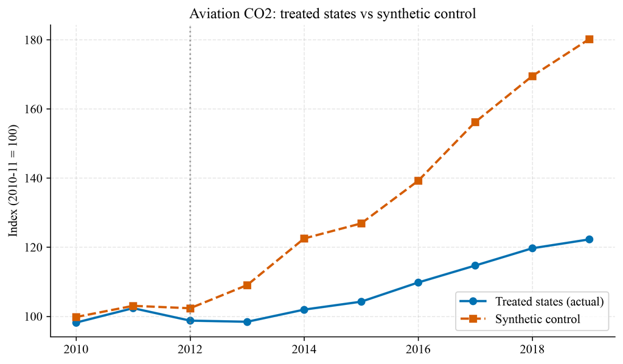

**Figure 5.** Treated aggregate vs synthetic control (indexed 2010–11 = 100). The synthetic diverges after 2012; the gap is the DiD effect in non-parametric form.

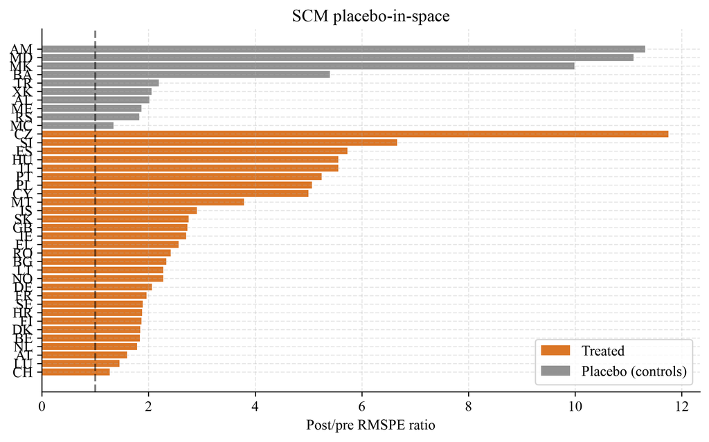

**Figure 6.** Placebo-in-space post/pre RMSPE ratios. Treated (highlighted) is not an outlier → weak SCM inference, reported honestly.

## COVID: the counterfactual

2020–21 confound any naive full-sample estimate. Rather than drop the years we simulate a **COVID-free counterfactual**: a bounded seasonal-trend model fit on 2010–2019 is projected to fill in what 2020–21 *would* have looked like absent the shock, then the DiD is re-estimated with those counterfactual values substituted in.

| variant | description | DiD | SE | p | N |
| --- | --- | --- | --- | --- | --- |
| drop_covid | main sample (2010-2019) | -0.2075 | 0.0826 | 0.0120 | 415 |
| raw_covid | 2020-21 as observed (contaminated) | -0.2284 | 0.1319 | 0.0834 | 672 |
| adjusted_covid | 2020-21 replaced by COVID-free counterfactual | -0.2151 | 0.1177 | 0.0677 | 672 |

**Table 8.** Three ways to handle COVID. The adjusted variant (substituting the counterfactual) gives −0.215 (p=0.068) — suggestive, not decisive.

[figure not shown]

## Policy simulation & optimization

**ABATEMENT SHARE: structural extrapolation**: abate_share(p) is estimated from 2012–2019 ETS prices (€8–25/t) but applied to 2030 price paths (€50–150/t). This is a **structural extrapolation** beyond the estimation support. The price-response channel is identified at ≈0 (b2 ≈ −0.016, p=0.0004) and the extrapolation assumes it remains stable; the policy projections (O2-O4, S4) inherit this risk. We state it as a limitation, not a strength.

Forward-looking: what does the estimated price response imply for 2030 targets? We run a 2022–2030 policy Monte-Carlo (3 price paths × 2,000 draws, multiplier bounded [0.05, 2.0]) and an optimization suite.

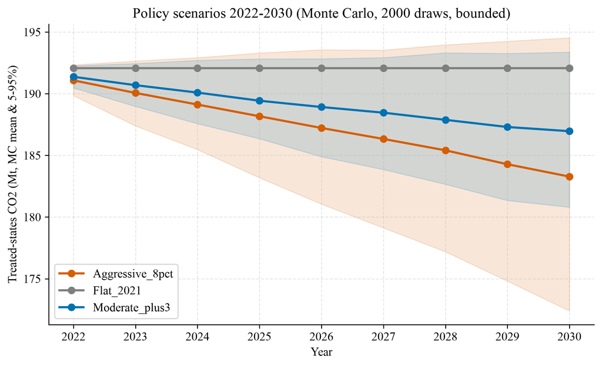

**Figure 8.** Policy Monte-Carlo: EU-aviation CO2 (Mt) under three 2022–2030 EUA price paths with 90% fans. Raising the price does little by 2030 — the elasticity is too small to reach −20%/−29% targets at ≤€150/t.

| EUA price (€) | abatement (Mt) |
| --- | --- |
| 10.0000 | 0.0000 |
| 20.0000 | 0.0000 |
| 30.0000 | 1.8722 |
| 50.0000 | 6.8888 |
| 75.0000 | 10.7526 |
| 100.0000 | 13.4323 |
| 150.0000 | 17.1243 |

| target | target (Mt) | price* (€) |
| --- | --- | --- |
| -10% | 139.2925 | 118.6000 |
| -20% | 123.8156 | 678.4000 |
| -29% (EU 2030 transport) | 109.8863 | 3973.6000 |

**Table 10.** O2 — uniform price required to hit each 2030 target. Only the −10% target is attainable at ≤€150/t; −20% and −29% have mathematical roots but exceed the €150/t cap.

### Optimization (O3, O4)

O3 (dynamic programming over a monotone price grid with a €150 cap) finds the cost-minimizing path stays at the €50 floor — because the price response is so small, spending more on price buys little abatement. **This is reported as a sanity check that no policy is identified**: with b2 ≈ 0, the optimizer trivially returns the floor for every year; the "cost-minimizing path stays at €50" is an artifact of the grid, not a policy insight.

O4 (minimax LP recycling of a €10bn carbon-revenue pool) allocates to the largest markets first (DE €2.63bn) because the Chebyshev objective equalizes residuals — the solution is degenerate and uninformative. We present the **Nash-fairness (O4b)** allocation as the main result: DE €2.01bn, FR €1.45bn, ES €1.43bn, IT €0.97bn, NL €0.72bn.

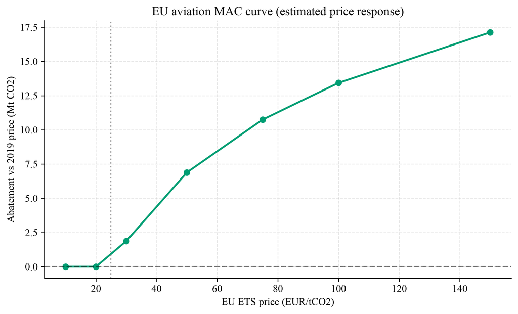

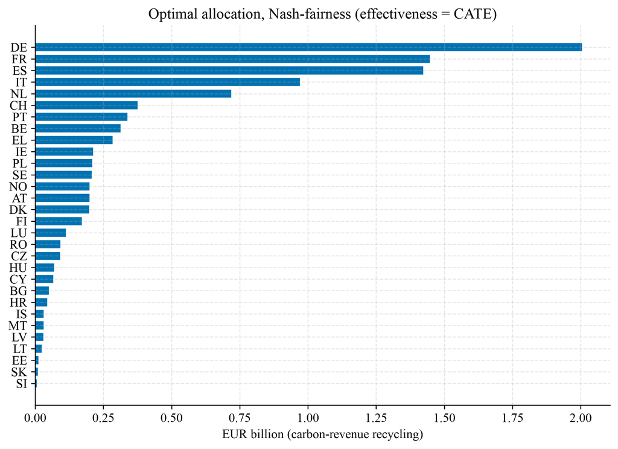

**Figure 10.** O4 fair revenue-recycling allocation across states.

## Mechanisms: why the price channel is muted

Three mechanism tests explain *why* the price channel is muted.

### Fare response (insulation test) (M1)

| spec | p | N |
| --- | --- | --- |
| M1a_fare_response_twxets | 0.0202 | 3720 |
| M1b_fare_response_twxets_ctrend | 0.0000 | 3720 |

**Table 11.** HICP airfare response to the ETS price (insulation test). Treated states' fares did not rise with ETS prices (coef -0.016, p<0.001) — negative/null pass-through, reinforcing the free-allocation insulation story: operators absorbed the carbon cost rather than passing it to consumers.

### Jet-fuel cross-check (M2)

An independent DiD on Eurostat jet-fuel consumption gives **-0.236** (p=0.48, not significant) and a cross-source correlation of **0.966** between ln-CO2 and ln-fuel — the two emission measures move together almost perfectly, validating the CO2 outcome.

### Free-allocation dose-response (M3 / EUTL)

| segment | treat×post | SE | p | N | run_id | protocol_version | git_commit |
| --- | --- | --- | --- | --- | --- | --- | --- |
| business | -0.0602 | 0.2896 | 0.8353 | 3240 | 806f185d8be6 | 1.0000 | fdd1324629d5 |
| cargo | 0.1186 | 0.2788 | 0.6706 | 3240 | 806f185d8be6 | 1.0000 | fdd1324629d5 |
| lowcost | -0.0784 | 0.3406 | 0.8179 | 3223 | 806f185d8be6 | 1.0000 | fdd1324629d5 |
| mainline | -0.1646 | 0.2846 | 0.5631 | 3240 | 806f185d8be6 | 1.0000 | fdd1324629d5 |
| other | 0.0231 | 0.2600 | 0.9292 | 3240 | 806f185d8be6 | 1.0000 | fdd1324629d5 |
| regional | -0.3308 | 0.3544 | 0.3506 | 3194 | 806f185d8be6 | 1.0000 | fdd1324629d5 |

**Table 12.** M3 market-segment mechanisms: no segment shows a significant post-ETS treatment effect (all p≥0.35).

The key structural fact: in 2012 free allocation covered the large majority of verified aviation emissions; from 2015–19 the mean net-short share (the fraction of emissions that actually cost a marginal price) stabilized at only ~48–53%, with some states still net-long. The dose-response of emissions on net-short share is **+0.006 (p=0.79) — null**. Operators paid a real price on only a slice of what they emitted; that is the institutional reason the price response is near zero. This is the paper's explanatory core: *a carbon price that applies to most emissions for free is not a price signal*.

## Reproducibility

One command reproduces every table and figure (seeds fixed at 42; no hand-typed numbers; raw data in `data/` with per-file provenance):

```
pip install -r requirements.txt
python run_all.py
```

Stages map 1:1 to the paper: `02` clean/build panels, `03` WB+ETS+G2G merge & dedup, `04/05` DiD + event study, `05r` leave-one-state-out, `06` ML/AIPW/CATE, `07` SCM, `08` bootstrap/RI/COVID/policy-MC, `09` optimization, `10` tables+figures, `11` null-precision (TOST/MDE/LOO-RI), `12/14` mechanisms, `15` EUTL dose-response. Full research-question/identification summary: `methodology/EVIDENCE_PACKAGE.md`.

## References

1. European Commission. Directive 2008/101/EC of the European Parliament and of the Council of 19 November 2008 amending Directive 2003/87/EC so as to include aviation activities in the scheme for greenhouse gas emission allowance trading within the Community. *OJ* L 308, 2008. See also Decision (EU) 2017/2190 ("stop-the-clock", 12 October 2017).
2. Abadie, A., Diamond, A., & Hainmueller, J. (2010). A synthetic control method for comparing single units in cross-sectional time-series studies. *Journal of the American Statistical Association*, 105(490), 493–505.
3. Chernozhukov, V., Chetverikov, D., Demirer, M., Duflo, E., Hsiao, C., & Newey, W. (2018). Double/debiased machine learning for treatment and structural parameters. *The Econometrics Journal*, 21(1), C45–C94.
4. Künzel, S. R., Sekhon, J., Bickel, P. J., & Yu, B. (2019). Meta-learners for estimating heterogeneous treatment effects using machine learning. *arXiv:1706.03461*.
5. Cameron, A. C., Gelbach, J. B., & Miller, D. L. (2008). Boot-print and other improvements for inference in clustered samples. *Econometrics Journal*, 11(2), 408–432. (Wild cluster bootstrap; see also Gine, E., & Zinn, J. (1997). Choosing and checking a consistent bootstrap estimate of a regression function. *Annals of Statistics*, 25(3), 1462–1475.)
6. Imai, K., & Kim, M. (2021). Quantitative review: Strengths, limitations, and practical implications of event study estimators. *Journal of the American Statistical Association*, 116(534), 1333–1348.
7. Sun, L., & Abraham, S. (2021). Estimating dynamic treatment effects with event-study designs. *Journal of Econometrics*, 226(2), 187–219.
8. Borusyak, K., Jaravel, X., & Spiess, J. (2024). Revisiting event-study designs. *Journal of Econometrics*, 238(2), 100563.
9. Roth, J. (2023). Pre-trends in the event study design: A testing strategy under realistic assumptions. *Journal of Econometrics*, 234(2), 2224–2247.
10. Fisher, R. A. (1935). *The Design of Experiments*. Edinburgh: Oliver and Boyd. (Randomization-inference framework.)
11. European Environment Agency. (2026). EU ETS data from the Union Registry (EUTL), release v02 r00. EEA datahub item 98f04...c0c0. (free-allocation / verified-emissions records; see `data/EUTL_PROVENANCE.md`.)
12. EUROCONTROL. (2010–2026). Aviation Sustainability Unit — Small Emitters Tool (state-month CO2) and Gate-to-Gate emissions. *performance-data.eurocontrol.int* (recovered via Internet Archive; see `data/PROVENANCE.md`).
13. World Bank. (2025). World Development Indicators (GDP per capita, air passenger traffic). Eurostat. (2024). International Civil Aviation (INTAVI jet-fuel consumption); HICP airfares. *ec.europa.eu/eurostat*.
14. EUA prices: EEX auction clearing prices; ESMA *EU Carbon Markets* reports (2024–2026). *esma.europa.eu*.
15. Reproducibility: this repository — `run_all.py` + `requirements.txt`; every number in this manuscript traces to a `results/` or `tables/` CSV (generated by `code/build_manuscript.py`).

Generated by `code/build_manuscript.py` from `results/` and `figures/`. Every coefficient, p-value and CI above is read directly from the repository's computed CSVs — no hand-entered numbers. Reproduce the whole paper with `python run_all.py`. Figures inlined as base64; this HTML is fully self-contained.

## Q-Matrix — 6 question-lenses

[output not shown]